# Visualizing genomic region data

Genomic data analysis requires integrated visualization of genomic information and experimental data. Popular genome browsers such as [ENSEMBL](https://www.ensembl.org/) and [UCSC](https://genome.ucsc.edu/) are typically used to display genome annotation data. However, customization of such visualization and overlay with additional experimental data does not meet the flexibility of the R graphics system. The Gviz package offers a flexible framework to visualize genomic data together with genome annotation features. It integrates with the GenomicRanges infrastructure, and provides data retrieval from external sources like [ENSEMBL](https://www.ensembl.org/) and [UCSC](https://genome.ucsc.edu/). This greatly facilitates customized visualization of experimental data and genomic anntation for specific genomic loci.

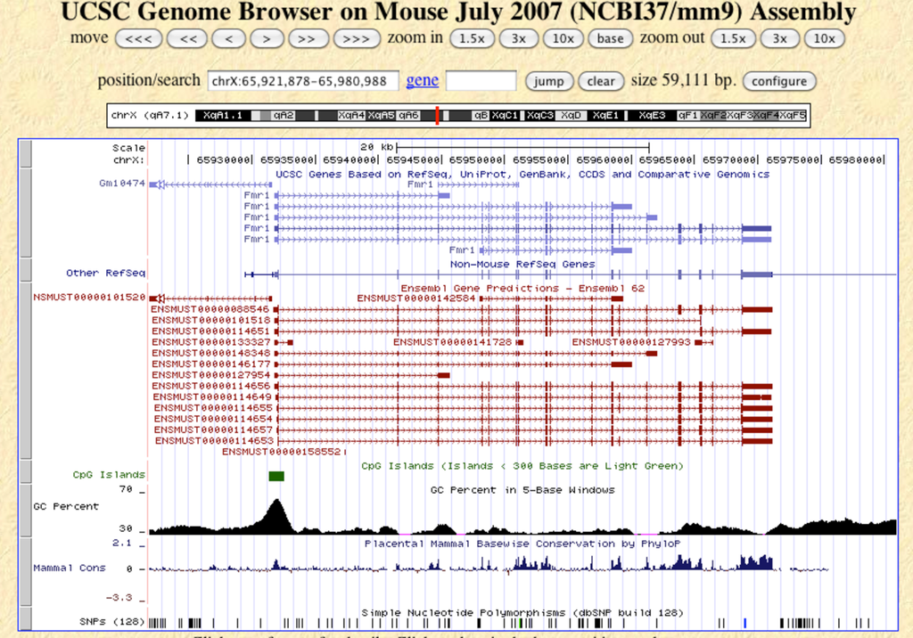

## Visualizing genomic region data from individual tracks

As for most genome browsers, the fundamental concept behind Gviz is that individual types of genomic features or data are represented by separate tracks. Each track is a single object, and there are constructors and methods to interact with and to plot these tracks.

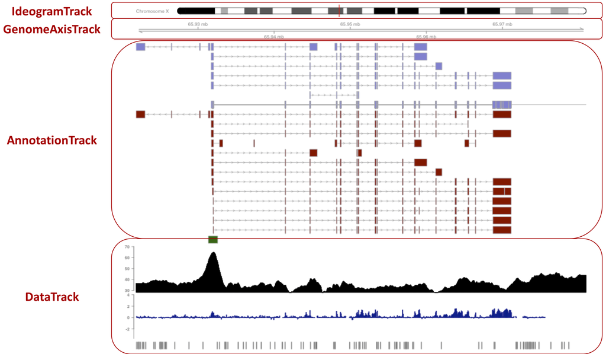

`Gviz` creates track objects from `GRanges` objects storing genomic region data. We consider an example set of CpG islands on chromosome 7 of the human hg19 genome assembly.

```r
library(Gviz)
library(GenomicRanges)
data(cpgIslands)
cpgIslands
```

```
## GRanges object with 10 ranges and 0 metadata columns:
##        seqnames            ranges strand
##           <Rle>         <IRanges>  <Rle>
##    [1]     chr7 26549019-26550183      *
##    [2]     chr7 26564119-26564500      *
##    [3]     chr7 26585667-26586158      *
##    [4]     chr7 26591772-26593309      *
##    [5]     chr7 26594192-26594570      *
##    [6]     chr7 26623835-26624150      *
##    [7]     chr7 26659284-26660352      *
##    [8]     chr7 26721294-26721717      *
##    [9]     chr7 26821518-26823297      *
##   [10]     chr7 26991322-26991841      *
##   -------
##   seqinfo: 1 sequence from hg19 genome; no seqlengths
```

### AnnotationTrack

Genomic annotation features such as exons, transcripts, and genes are represented by `AnnotationTrack` objects. We use the constructor function to create an annotation track representing the genomic coordinates of the example set of CpG islands.

```r
atrack <- AnnotationTrack(cpgIslands, name="CpG")
```

Individual tracks are displayed with the `plotTracks` function.

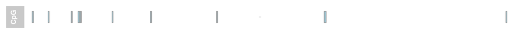

```r
plotTracks(atrack)
```

Apart from the relative distance of the CpG islands, this visualization is not very informative. For reference, we need the genomic coordinates that we are currently looking at.

### GenomeAxisTrack

For this purpose, we construct a `GenomeAxisTrack`.

```r
gtrack <- GenomeAxisTrack()
```

A `GenomeAxisTrack` object is always relative to the other tracks that are plotted, and we can pass this additional track on to `plotTracks` in the form of a list.

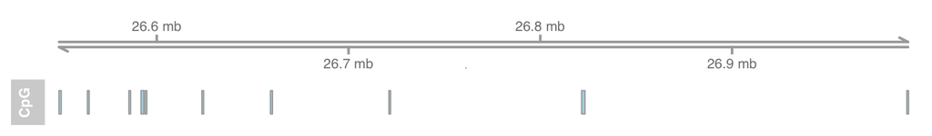

```r
plotTracks(list(gtrack, atrack))
```

### IdeogramTrack

Each track is defined for a chromosome on a specified genome. This information can be displayed by a chromosome ideogram. An ideogram is a simplified visual representation of a chromosome, indicating the location of the centromere and chromosomal staining bands. Chromosome information is available from online repositories such as UCSC. The `IdeogramTrack` constructor allows to conviently retrieve this information, given the genome and chromosome under consideration.

```r
itrack <- IdeogramTrack(genome="hg19", chromosome="chr7")
```

As before, we combine the additional ideogram track object with the other two tracks in a list and plot it with `plotTracks`.

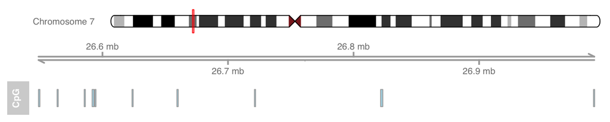

```r
plotTracks(list(itrack, gtrack, atrack))
```

The genomic region under consideration is indicated on the chromosome by a red box (or, as in this case, a red line if the width is too small to fit a box).

### GeneRegionTrack

So far, we looked at basic annotation features and how to illustrate the chromosomal location. The `GeneRegionTrack` is a specialized `AnnotationTrack` representing more complex annotation features such as gene models. For demonstration, we use example gene model data contained in the `Gviz` package,

```r
data(geneModels)
geneModels <- makeGRangesFromDataFrame(geneModels, keep.extra.columns=TRUE)
geneModels
```

```
## GRanges object with 97 ranges and 5 metadata columns:
##        seqnames            ranges strand |        feature            gene
##           <Rle>         <IRanges>  <Rle> |       <factor>        <factor>
##    [1]     chr7 26591441-26591829      + |        lincRNA ENSG00000233760
##    [2]     chr7 26591458-26591829      + |        lincRNA ENSG00000233760
##    [3]     chr7 26591515-26591829      + |        lincRNA ENSG00000233760
##    [4]     chr7 26594428-26594538      + |        lincRNA ENSG00000233760
##    [5]     chr7 26594428-26596819      + |        lincRNA ENSG00000233760
##    ...      ...               ...    ... .            ...             ...
##   [93]     chr7 26904461-26904732      - | protein_coding ENSG00000005020
##   [94]     chr7 26933458-26933479      - | protein_coding ENSG00000005020
##   [95]     chr7 26933480-26933592      - |           utr5 ENSG00000005020
##   [96]     chr7 27022387-27022986      - |     pseudogene ENSG00000226059
##   [97]     chr7 27034774-27034858      - |           utr5 ENSG00000005020
##                   exon      transcript     symbol
##               <factor>        <factor>   <factor>
##    [1] ENSE00001693369 ENST00000420912 AC004947.2
##    [2] ENSE00001596777 ENST00000457000 AC004947.2
##    [3] ENSE00001601658 ENST00000430426 AC004947.2
##    [4] ENSE00001792454 ENST00000457000 AC004947.2
##    [5] ENSE00001618328 ENST00000420912 AC004947.2
##    ...             ...             ...        ...
##   [93] ENSE00001818170 ENST00000481204      SKAP2
##   [94] ENSE00001686825 ENST00000432747      SKAP2
##   [95] ENSE00001686825 ENST00000432747      SKAP2
##   [96] ENSE00001769159 ENST00000417997   HMGB3P20
##   [97] ENSE00001609754 ENST00000432747      SKAP2
##   -------
##   seqinfo: 1 sequence from an unspecified genome; no seqlengths
```

and add a `GeneRegionTrack` to the genomic plot.

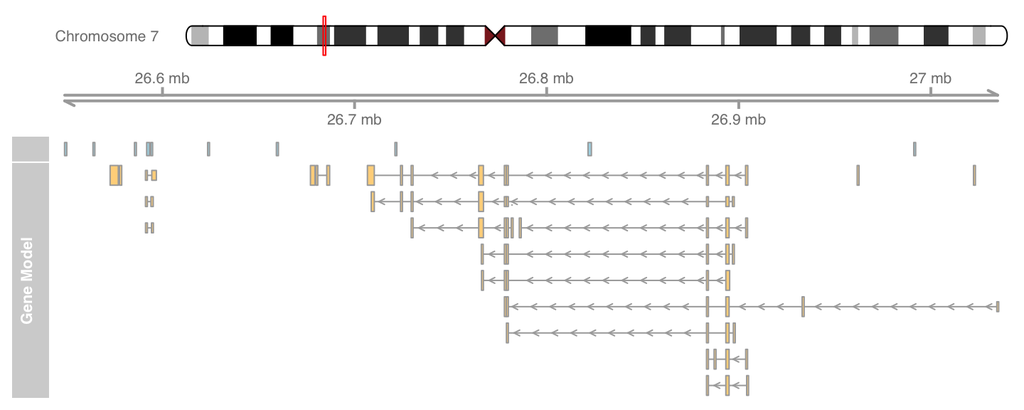

```r
grtrack <- GeneRegionTrack(geneModels, name="Gene Model")
plotTracks(list(itrack, gtrack, atrack, grtrack))
```

To identify each transcript, we can annotate e.g. the corresponding gene symbol.

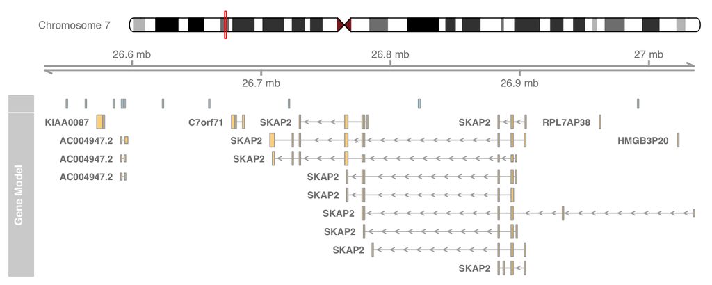

```r
grtrack <- GeneRegionTrack(geneModels, name="Gene Model", transcriptAnnotation="symbol")
plotTracks(list(itrack, gtrack, atrack, grtrack))
```

### DataTrack

Displaying genome annotation in a genomic region of interest can also be done in online genome browsers. The real power of the `Gviz` package lies in plotting additional data from experiments or computations with the general `DataTrack`. A `DataTrack` is essentially a run-length encoded numeric vector or matrix, and we can use such a track to add all sorts of numeric data to a genomic region plot. Various visualization options are available for these tracks, including dot plots, histograms, and boxplots.

For demonstration, we create a simple `DataTrack` from randomly sampled scores for each CpG island.

```r
cpgIslands$score <- runif(length(cpgIslands), min = 1, max = 100)
cpgIslands
```

```
## GRanges object with 10 ranges and 1 metadata column:
##        seqnames            ranges strand |            score
##           <Rle>         <IRanges>  <Rle> |        <numeric>
##    [1]     chr7 26549019-26550183      * | 46.8292105873115
##    [2]     chr7 26564119-26564500      * | 7.76783817773685
##    [3]     chr7 26585667-26586158      * | 24.4340119995177
##    [4]     chr7 26591772-26593309      * | 39.5902740377933
##    [5]     chr7 26594192-26594570      * | 51.2705220603384
##    [6]     chr7 26623835-26624150      * | 69.0322449547239
##    [7]     chr7 26659284-26660352      * | 30.7628846149892
##    [8]     chr7 26721294-26721717      * | 75.2831663819961
##    [9]     chr7 26821518-26823297      * | 20.9586979732849
##   [10]     chr7 26991322-26991841      * | 37.4527341248468
##   -------
##   seqinfo: 1 sequence from hg19 genome; no seqlengths
```

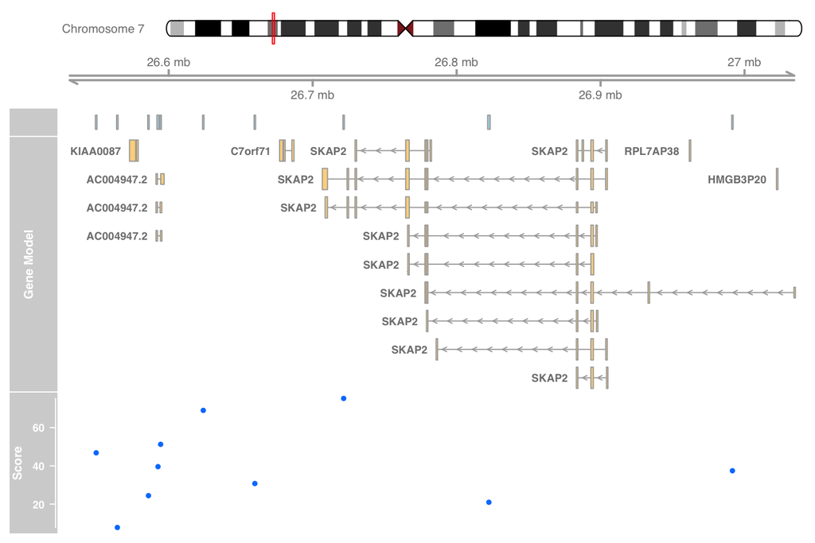

```r
dtrack <- DataTrack(cpgIslands, name="Score")
plotTracks(list(itrack, gtrack, atrack, grtrack, dtrack))
```

The scores are matched to the genomic coordinates of the DataTrack.

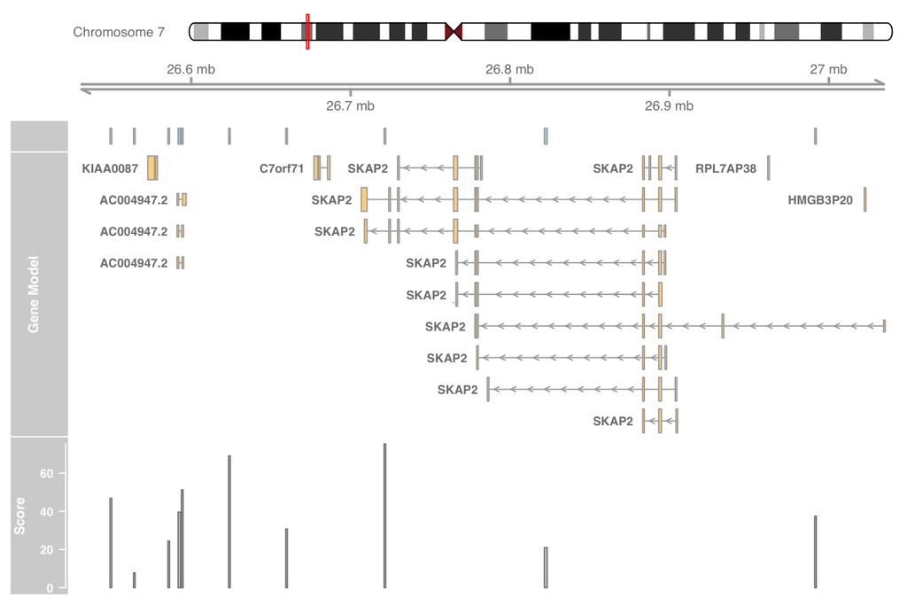

```r
dtrack <- DataTrack(cpgIslands, name="Score", type="histogram")
plotTracks(list(itrack, gtrack, atrack, grtrack, dtrack))
```

## Exercises (10 min)

1. Use the `littleTicks` display parameter to construct a more fine-grained `GenomeAxisTrack`.
2. Annotate transcripts in the `GeneRegionTrack` with ENSEMBL transcript ID instead of gene symbol.
3. Add an additional data track that displays the width of each CpG island.